# Tuberculosis

## Introduction

Tuberculosis still remains highly prevalent in The Gambia with rates at 128 cases per 100,000 population**.** It is often difficult to diagnose (especially in children) and requires a combination of clinical history, examination and diagnostics.

## Target users

- Nurses
- Doctors

## Target area of use

- Gate clinic
- Outpatient clinic
- Ward

## Key areas of focus / New additions / Changes

This guideline outlines the investigation and treatment of TB.

## Limitations

Please also refer to the SOP on investigation of TB (SOP-CLS-003) to ensure proper use of our diagnostic resources.

## Presenting symptoms and signs

- Fever
- Night sweats
- Weight loss
- Cough

*For two weeks or more*

### Important things to ask

- Previous TB diagnosis
- Any contacts who have chronic cough, has had TB or currently on treatment
- HIV status – being HIV positive increases risk of having TB and complicates treatment
- Smoking status

## Examination findings

Typical findings include:

- Wasting
- Lymphadenopathy
- Respiratory examination; any signs of respiratory distress, chest may be clear, other signs of consolidation or collapse

### Important things to look for:

- Signs of immunosuppression,
- Signs of extra-pulmonary TB (gibbus, organomegaly, skin lesions, bony lesions)

## Differential diagnoses

- Pneumonia
- Underlying chronic lung disease
- Lung cancer

## Investigations

General investigations that might be useful for more complex patients, but do not need to be done routinely:

- FBC – to look for signs of acute infection.
- Urea & electrolytes – for baseline.
- Liver function tests – baseline before starting anti-TB treatment.

Important investigations to diagnose TB:

- Chest x-ray (findings typical of TB include upper zone collapse or consolidation).
- Sputum x 2 for Acid fast bacilli (ask patient to cough and produce sputum into 2 labelled sputum pots, request sputum for AFB on EMRS – the patient or nurse should deliver them to the TB clinic and ask the attendant to sign them into the fridge).
- NB: Send to TB clinic for sputum induction if producing quality sputum is a challenge.

For children in whom TB is suspected and the sputum is either difficult to collect or shows AFB negative, ask TB clinic to review. They may suggest gastric washings or sputum induction.

Gene Xpert (TB PCR test): This is indicated for patients with possible extra-pulmonary TB, for patients known to have HIV and for those patients who have had negative AFBs but who are thought to have TB. Please see the separate SOP on Investigation of TB (SOP-CLS-003).

HIV test (if status unknown) should be done for all patients diagnosed with TB.

## Management

Assess whether the patient requires admission based on your clinical examination and early warning score.

Note all children with either confirmed or suspected TB should be referred to the childhood TB team. All adults with sputum positive TB should be referred to the TB clinic. These patients are eligible for recruitment into TB studies.

### If clinically unwell, needs admission

Admit to a side room for adults and adolescents with pulmonary TB. If a side room is not available, the patient must be transferred elsewhere.

- Start IV antibiotics (see sepsis guideline).
- IV fluids if indicated.
- Ensure necessary bloods and sputum samples are collected.

### Clinically well

Review in 1 week with results. In meantime, treat for a lower respiratory tract infection if indicated.

Treat according to results:

- Sputum positive – refer to TB clinic.
- Sputum negative but high suspicion of TB – if you are convinced this is TB, refer for treatment of sputum negative TB via TB clinic. If you are unsure, discuss with TB team to agree on further assessment.
- Sputum negative and improved symptoms – consider discharge or follow up in 1 month to ensure improvement persists.

### Anti-TB medication

Combination therapy of Rifampicin, Isoniazid, Pyrazinamide and Ethambutol. Add pyridoxine 25 mg OD orally to prevent peripheral neuropathy.

Medication comes as a combination therapy (TB4) – the number of tablets depends on the weight of the patient.

Patients will need referral to national treatment centre for follow up and treatment at diagnosis for outpatients or at discharge for inpatients. This can be arranged by sending them to the TB clinic.

## Key Issues for Nursing care

Nurses’ role in OPD:

- Make sure the sputum samples are adequate.
- Properly label samples.
- Deposit in fridge in TB clinic; *samples need to be signed in to the book on top of TB fridge.*

## References

A Tuberculosis Nationwide Prevalence Survey in Gambia 2012. Adetifa I et al. Bulletin World Health Organisation 2016; 94:433-441 doi: http://dx.doi.org/10.2471/BLT.14.151670

Tuberculosis. Pai M et al. Nature, Article number : 16076, volume 2 DOI 10.1038/nrdp.2016.76. Published online 27 Oct 2016.

| **Written by:** | Name: Caitlin Jones | Date: 6 June 2018 |
| --- | --- | --- |
| **Reviewed by:** | Name: Babatunde Awokola | Date: 17 July 2018 |
| **Version:** | **Change history:** | **Review due date:** |
| 1.0 | New document | 31 July 2020 |
| 1.1 | Executive summary added | 31 July 2020 |
| Review Comments (*if applicable)* |  |  |

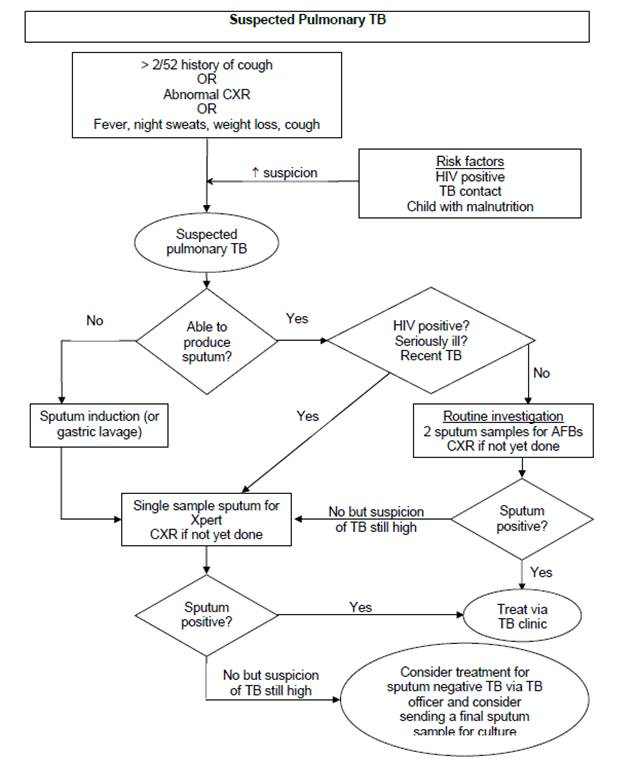

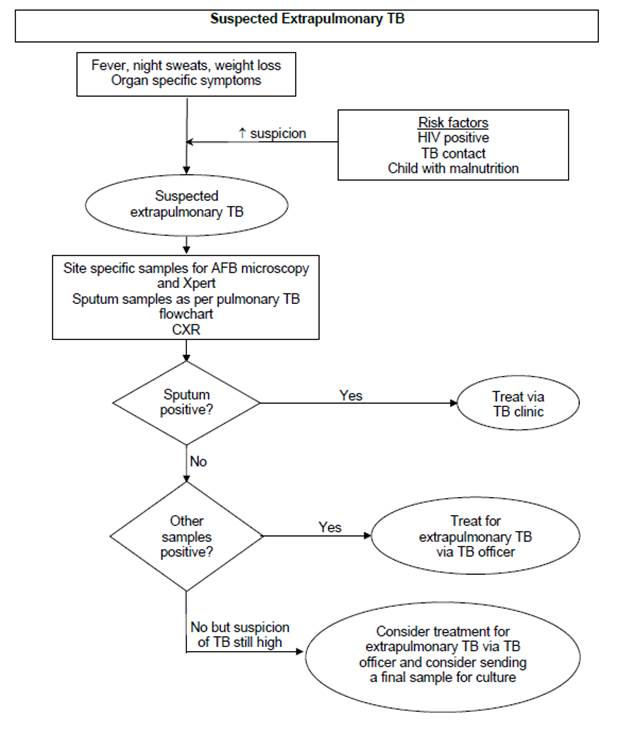